# Global Energy Consumption for Sustainable Development

**Group Members:** Frank Kuukyee, Deysy Londono, Rookayat Adedo, Yao Zhong.

## 1. Introduction

Our everyday lives depend on reliable and affordable energy. A well-established energy system supports all sectors: from businesses, health services, education to agriculture[1]. Electricity use is rising fast everywhere, it is estimated that its consumption will increase by 50% from 2021 to 2040 [2], and without a stable electricity supply, our society will not be able to function properly.

However, still many countries lack or have limited access to electricity; more that 800 million people live without access to this basic service. This figure corresponds approximately to one seventh of the world population. This is one reason why the United Nations have included "Affordable and Clean Energy" as one of the 17 Goals in its agenda for sustainable development provides a shared blueprint for peace and prosperity for people and the planet, now and into the future.

Understanding how energy is used globally is essential to decoding patterns, anticipating energy demands, enabling energy suppliers to optimize energy distribution, and allowing governments and agencies to focus resources towards the afformentioned goal.

Energy resources, such as oil, gas, and coal, are not evenly distributed globally, which creates disparities in energy access. Countries with abundant energy resources can significantly influence global energy markets, while regions with limited access to energy resources face challenges in meeting their energy demands, holding back economic development, and worsening socioeconomic disparities.

**Expected Outcome.** While this dataset holds great potential, we will focus our attention on developing a few models that that will enable us to predict if a country has mode that 99% access to electricity and determine which of these models would better serve the purpose.

## 2. Dataset

The "Global Data on Sustainable Energy" dataset [3] is a comprehensive collection of data spanning various countries and years, focusing on sustainable energy and its socioeconomic implications. It consists of 3,649 rows and 21 columns, covering a wide range of indicators such as access to electricity, renewable energy capacity, financial flows to developing countries for sustainable projects, the mix of energy sources (including fossil fuels, nuclear, and renewables), and CO2 emissions. Additionally, it includes key economic metrics like GDP growth and per capita values, along with geographical data like population density, land area, and coordinates. This dataset is a valuable resource for analyzing global trends in sustainable energy, economic development, and their environmental impacts.

| Column Name | Description |
| --- | --- |
| Entity | The name of the country or region for which the data is reported |
| Year | The year for which the data is reported (2000 to 2020) |
| Access to electricity | The percentage of population with access to electricity |
| Access to clean fuels for cooking | The percentage of the population with primary reliance on clean fuels |
| Renewable-electricity-generating-capacity-per-capita | Installed Renewable energy capacity per person |
| Financial flows to developing countries (US $) | Aid and assistance from developed countries for clean energy projects |
| Renewable energy share in total final energy consumption (%) | Percentage of renewable energy in final energy consumption |
| Electricity from fossil fuels (TWh) | Electricity generated from fossil fuels (coal, oil, gas) in terawatt-hours |
| Electricity from nuclear (TWh) | Electricity generated from nuclear power in terawatt-hours |
| Electricity from renewables (TWh) | Electricity generated from renewable sources (hydro, solar, wind, etc.) in terawatt-hours |
| Low-carbon electricity (% electricity) | Percentage of electricity from low-carbon sources (nuclear and renewables) |
| Primary energy consumption per capita (kWh/person) | Energy consumption per person in kilowatt-hours |
| Energy intensity level of primary energy | Energy use per unit of GDP at purchasing power parity |
| Value_co2_emissions (metric tons per capita) | Carbon dioxide emissions per person in metric tons |
| Renewables (% equivalent primary energy) | Equivalent primary energy that is derived from renewable sources |
| GDP growth (annual %) | Annual GDP growth rate based on constant local currency |
| GDP per capita | Gross domestic product per person |
| Density (P/Km2) | Population density in persons per square kilometer |
| Land Area (Km2) | Total land area in square kilometers |
| Latitude | Latitude of the country's centroid in decimal degrees |
| Longitude | Longitude of the country's centroid in decimal degrees |

This dataset will serve as the foundation for our analysis, enabling us to dissect energy usage patterns and predict future trends.

## 3. Methodology.

The table below shows the first five rows of the original dataset `Global Data on Sustainable energy.csv`.

```python
import numpy as np
import pandas as pd
import seaborn as sns
import plotly.express as px
import matplotlib.pyplot as plt
import warnings
import statsmodels.api as sm
from sklearn.linear_model import LogisticRegression
from sklearn.metrics import accuracy_score
from sklearn.impute import KNNImputer
from sklearn.metrics import accuracy_score,mean_squared_error,mean_absolute_error,r2_score
from sklearn.ensemble import RandomForestRegressor

warnings.filterwarnings("ignore")

original_df = pd.read_csv('https://raw.githubusercontent.com/ddlondono/DATA606/main/Sustainable_Energy_Dataset.csv')
original_df.head()
```

|  | Entity | Year | Access to electricity (% of population) | Access to clean fuels for cooking | Renewable-electricity-generating-capacity-per-capita | Financial flows to developing countries (US $) | Renewable energy share in the total final energy consumption (%) | Electricity from fossil fuels (TWh) | Electricity from nuclear (TWh) | Electricity from renewables (TWh) | ... | Primary energy consumption per capita (kWh/person) | Energy intensity level of primary energy (MJ/$2017 PPP GDP) | Value_co2_emissions_kt_by_country | Renewables (% equivalent primary energy) | gdp_growth | gdp_per_capita | Density(P/Km2) | Land Area(Km2) | Latitude | Longitude |
| --- | --- | --- | --- | --- | --- | --- | --- | --- | --- | --- | --- | --- | --- | --- | --- | --- | --- | --- | --- | --- | --- |
| 0 | Afghanistan | 2000 | 1.613591 | 6.2 | 9.22 | 20000.0 | 44.99 | 0.16 | 0.0 | 0.31 | ... | 302.59482 | 1.64 | 760.000000 | NaN | NaN | NaN | 60 | 652230.0 | 33.93911 | 67.709953 |
| 1 | Afghanistan | 2001 | 4.074574 | 7.2 | 8.86 | 130000.0 | 45.60 | 0.09 | 0.0 | 0.50 | ... | 236.89185 | 1.74 | 730.000000 | NaN | NaN | NaN | 60 | 652230.0 | 33.93911 | 67.709953 |
| 2 | Afghanistan | 2002 | 9.409158 | 8.2 | 8.47 | 3950000.0 | 37.83 | 0.13 | 0.0 | 0.56 | ... | 210.86215 | 1.40 | 1029.999971 | NaN | NaN | 179.426579 | 60 | 652230.0 | 33.93911 | 67.709953 |
| 3 | Afghanistan | 2003 | 14.738506 | 9.5 | 8.09 | 25970000.0 | 36.66 | 0.31 | 0.0 | 0.63 | ... | 229.96822 | 1.40 | 1220.000029 | NaN | 8.832278 | 190.683814 | 60 | 652230.0 | 33.93911 | 67.709953 |
| 4 | Afghanistan | 2004 | 20.064968 | 10.9 | 7.75 | NaN | 44.24 | 0.33 | 0.0 | 0.56 | ... | 204.23125 | 1.20 | 1029.999971 | NaN | 1.414118 | 211.382074 | 60 | 652230.0 | 33.93911 | 67.709953 |

5 rows × 21 columns

## 3.1. Pre-Processing of the Data

To begin with, we checked for missing data in the dataset and found that some columns have a signifficant number of missing values, in some cases more that 50%. Since deleting missing values in a dataset can lead to several drawbacks, a preliminary analysis using a random sample and OLS method is performed to ensure that our analysis would be based on the most complete information possible.

```python
features=original_df.columns.values
missing_val=original_df.isnull().sum()
non_missing_val= original_df.notnull().sum()
total_val=original_df.shape[0]
percentage_missing=missing_val/total_val*100
percentage_missing
```

```
Entity                                                               0.000000
Year                                                                 0.000000
Access to electricity (% of population)                              0.274048
Access to clean fuels for cooking                                    4.631406
Renewable-electricity-generating-capacity-per-capita                25.513839
Financial flows to developing countries (US $)                      57.248561
Renewable energy share in the total final energy consumption (%)     5.316525
Electricity from fossil fuels (TWh)                                  0.575500
Electricity from nuclear (TWh)                                       3.453001
Electricity from renewables (TWh)                                    0.575500
Low-carbon electricity (% electricity)                               1.151000
Primary energy consumption per capita (kWh/person)                   0.000000
Energy intensity level of primary energy (MJ/$2017 PPP GDP)          5.672787
Value_co2_emissions_kt_by_country                                   11.729241
Renewables (% equivalent primary energy)                            58.563990
gdp_growth                                                           8.687312
gdp_per_capita                                                       7.728145
Density(P/Km2)                                                       0.027405
Land Area(Km2)                                                       0.027405
Latitude                                                             0.027405
Longitude                                                            0.027405
dtype: float64
```

### 3.1.1. OLS Model

To ensure that some columns of missing data can actually be ommited form our analysis, we run a linear regression includiig all the features and using as a sample all the entries that are complete. This model will not serve our original purpose of predicting, but will be useful to know the significance of each of the variables.

```python
original_df['Density(P/Km2)'] = original_df['Density(P/Km2)'].replace(',', '', regex=True).astype(float)
df_ols = original_df.dropna()
X = sm.add_constant(df_ols.drop(['Entity', 'Year', 'Access to electricity (% of population)'], axis=1))
ols_model = sm.OLS(df_ols['Access to electricity (% of population)'], X)                        # Fit the linear regression model
results = ols_model.fit()                                    # Perform the regression
print(results.summary())
```

```
                                       OLS Regression Results
===================================================================================================
Dep. Variable:     Access to electricity (% of population)   R-squared:                       0.787
Model:                                                 OLS   Adj. R-squared:                  0.775
Method:                                      Least Squares   F-statistic:                     66.39
Date:                                     Mon, 19 Feb 2024   Prob (F-statistic):           4.26e-97
Time:                                             16:05:33   Log-Likelihood:                -1108.9
No. Observations:                                      343   AIC:                             2256.
Df Residuals:                                          324   BIC:                             2329.
Df Model:                                               18
Covariance Type:                                 nonrobust
====================================================================================================================================
                                                                       coef    std err          t      P>|t|      [0.025      0.975]
------------------------------------------------------------------------------------------------------------------------------------
const                                                               83.3384      5.404     15.422      0.000      72.707      93.969
Access to clean fuels for cooking                                    0.0245      0.051      0.484      0.629      -0.075       0.124
Renewable-electricity-generating-capacity-per-capita                 0.0378      0.010      3.730      0.000       0.018       0.058
Financial flows to developing countries (US $)                    1.527e-10   9.73e-10      0.157      0.875   -1.76e-09    2.07e-09
Renewable energy share in the total final energy consumption (%)    -0.4924      0.066     -7.406      0.000      -0.623      -0.362
Electricity from fossil fuels (TWh)                                  0.0101      0.009      1.180      0.239      -0.007       0.027
Electricity from nuclear (TWh)                                       0.0301      0.058      0.521      0.603      -0.084       0.144
Electricity from renewables (TWh)                                   -0.0426      0.011     -3.826      0.000      -0.065      -0.021
Low-carbon electricity (% electricity)                               0.2280      0.093      2.446      0.015       0.045       0.411
Primary energy consumption per capita (kWh/person)                   0.0002   9.58e-05      1.914      0.057   -5.11e-06       0.000
Energy intensity level of primary energy (MJ/$2017 PPP GDP)         -1.1552      0.255     -4.523      0.000      -1.658      -0.653
Value_co2_emissions_kt_by_country                                -2.069e-06    3.4e-06     -0.609      0.543   -8.76e-06    4.62e-06
Renewables (% equivalent primary energy)                             0.0840      0.198      0.424      0.672      -0.306       0.474
gdp_growth                                                           0.1116      0.087      1.282      0.201      -0.060       0.283
gdp_per_capita                                                       0.0012      0.000      4.537      0.000       0.001       0.002
Density(P/Km2)                                                      -0.0131      0.002     -5.381      0.000      -0.018      -0.008
Land Area(Km2)                                                    1.189e-06   3.74e-07      3.180      0.002    4.53e-07    1.92e-06
Latitude                                                             0.1935      0.025      7.863      0.000       0.145       0.242
Longitude                                                            0.0933      0.011      8.538      0.000       0.072       0.115
==============================================================================
Omnibus:                       28.749   Durbin-Watson:                   0.490
Prob(Omnibus):                  0.000   Jarque-Bera (JB):               49.611
Skew:                           0.518   Prob(JB):                     1.69e-11
Kurtosis:                       4.549   Cond. No.                     6.76e+09
==============================================================================

Notes:
[1] Standard Errors assume that the covariance matrix of the errors is correctly specified.
[2] The condition number is large, 6.76e+09. This might indicate that there are
strong multicollinearity or other numerical problems.
```

This approach allowed us to keep valuable data for our analysis while ensuring that our dataset was as complete and accurate as possible.

## 4. Exploratory analysis

This section will consist on exploring and visualizing different variables such us access to electricity by country, Access to clean fuels for cooking, relationship between compsumption of energy and GDP, etc.

The following heatmap, shows in dark blue tones the variables that are more positively correlated.

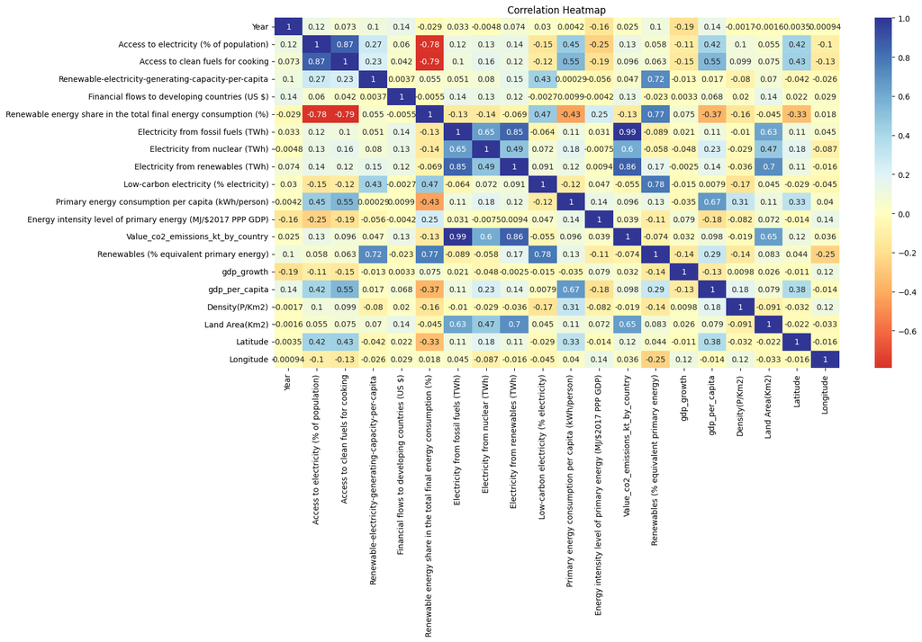

```python
df=original_df.copy()
cm = df.corr()
plt.figure(figsize=(16, 8))
sns.heatmap(cm, annot=True, cmap='RdYlBu', center=0)
plt.title('Correlation Heatmap')
plt.show()
```

*Please note that this correlation heatmap shows only linear correlation between the variables, any non-linear relationship is not reflected in this heatmap.*

The following histogram shows the distribution of access to electricity across different countries in the dataset. The curved KDE line (known as Kernel Density Estimate) gives a smooth estimate of the distribution, showing where the data points are concentrated.

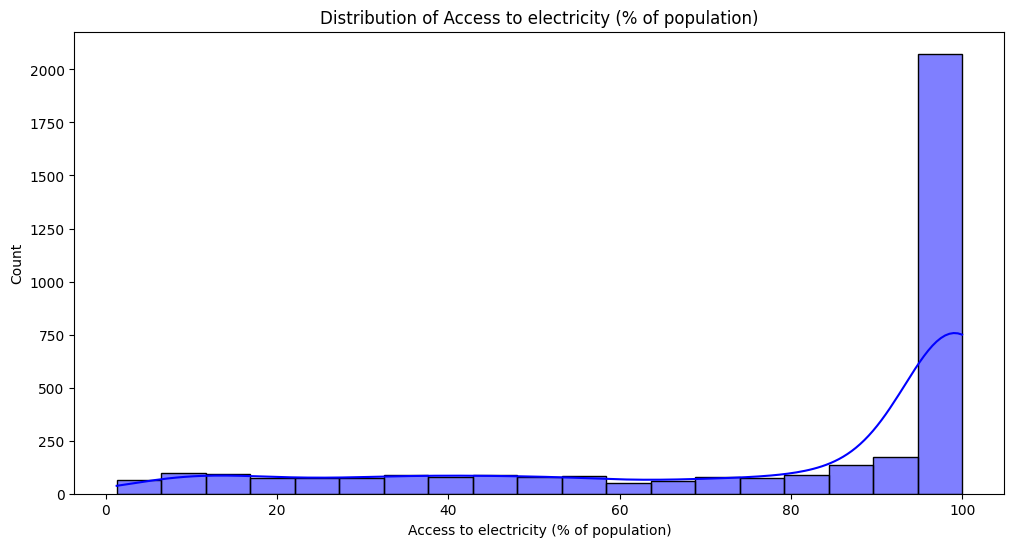

```python
# Distribution Plot for 'Access to electricity (% of population)'
plt.figure(figsize=(12, 6))
sns.histplot(df['Access to electricity (% of population)'].dropna(), kde=True, color="blue")
plt.title('Distribution of Access to electricity (% of population)')
plt.xlabel('Access to electricity (% of population)')
plt.show()
```

In the following bubble chart we can visualize the relationship between access to electricity and GDP per capita, with the size of each bubble representing the GDP per capita. The bubble chart offers a multi-dimensional view of the data and can be particularly useful for identifying patterns and correlations.

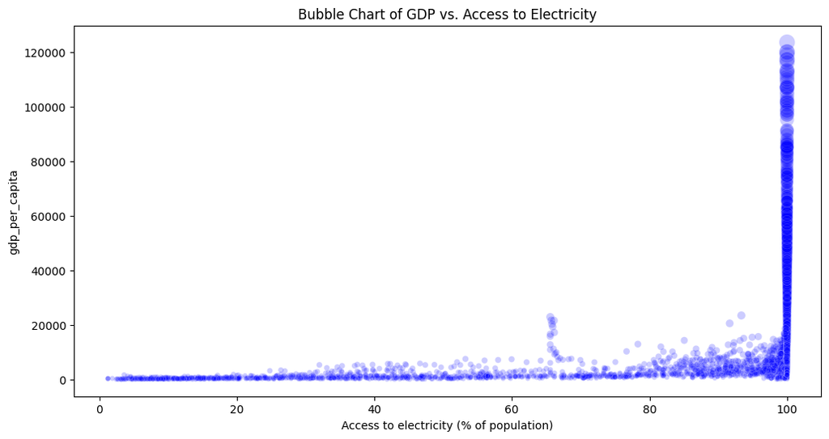

```python
# Bubble Chart of GDP vs. Access to Electricity
plt.figure(figsize=(12, 6))
sns.scatterplot(
    data=df,
    x='Access to electricity (% of population)',
    y='gdp_per_capita',
    size='gdp_per_capita',
    color="blue",
    legend=False,
    sizes=(20, 200),
    alpha=0.2
)
plt.title('Bubble Chart of GDP vs. Access to Electricity')
plt.show()
```

The scatter plot matrix below shows the bivariate relationships between different combinations of selected variables from the dataset. The selected variables are Access to electricity (% of population), Access to clean fuels for cooking, Renewable energy share in the total final energy consumption (%), gdp_per_capita, and Primary energy consumption per capita (kWh/person). The scatter plot matrix provides a visual summary that can help identify which variables might be worth investigating further in a predictive model or other detailed analyses. The scatter plots also reveal different types of relationships: positive correlation (as one variable increases, so does the other), negative correlation (as one variable increases, the other decreases), or no correlation (variables do not show any clear relationship). These relationships help to hypothesize about potential causes and effects.

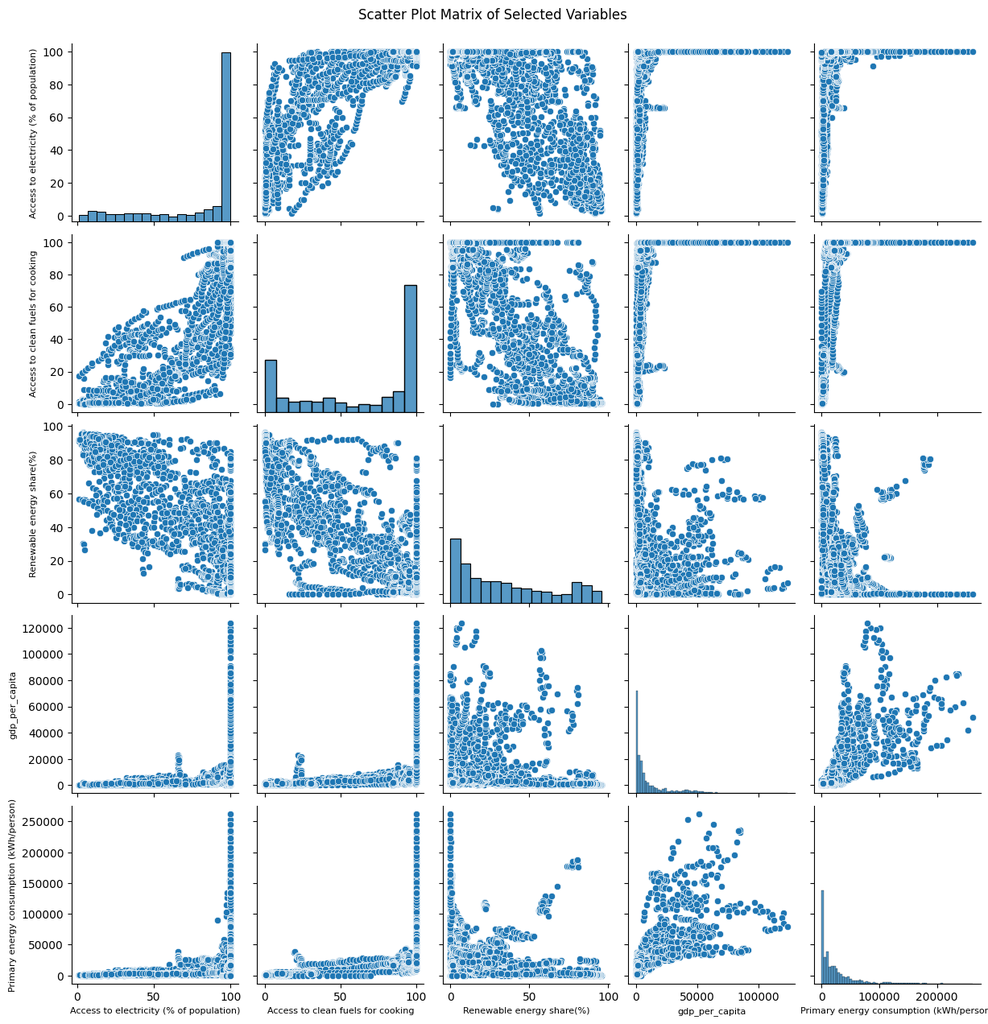

```python
selected_columns = ['Access to electricity (% of population)', 'Access to clean fuels for cooking',
                    'Renewable energy share in the total final energy consumption (%)',
                    'gdp_per_capita', 'Primary energy consumption per capita (kWh/person)']
pairplot_df = df[selected_columns].dropna()
pairplot_df.rename(
    columns={"Renewable energy share in the total final energy consumption (%)": "Renewable energy share(%)",
             'Primary energy consumption per capita (kWh/person)':'Primary energy consumption (kWh/person)'},
    inplace=True,
)

pair_plot = sns.pairplot(pairplot_df)
for ax in pair_plot.axes.flatten():
    ax.set_xlabel(ax.get_xlabel(), fontsize=8)
    ax.set_ylabel(ax.get_ylabel(), fontsize=8)
plt.suptitle('Scatter Plot Matrix of Selected Variables', y=1.02)
plt.show()
```

Observations:

- Diagonal Histograms: The diagonal plots are histograms showing the distribution of each variable independently. For example, we can see the distribution of access to electricity, where most of the data points are clustered towards higher percentages, suggesting that most of the included entities have high access to electricity.
- Off-diagonal Scatter Plots: Each off-diagonal plot shows the relationship between two different variables. For instance, the scatter plot for 'Access to electricity (% of population)' vs. 'gdp_per_capita' indicates that higher GDP per capita corresponds with better access to electricity.
- Trends and Correlations: We also notice varying degrees of correlation between different pairs of variables in the dataset. Some variables like GDP per capita and primary energy consumption per capita seem to have a positive correlation while others are more dispersed.
- Density of Points: The concentration of points within a scatter plot indicates the commonality of certain variable combinations. For example, many points are bunched together at high values of GDP and high access to electricity suggests that these two factors often occur together.

The next heatmap shows the average annual access to electricity by continent and their respective GDP per capita. It effectively illustrates the relationship between electricity access and the economic strength of the region, highlighting disparities and progress over time.

```python
!pip install pycountry_convert --quiet
```

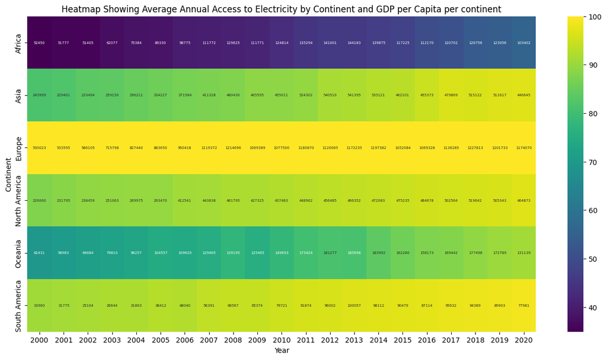

```python
import pycountry_convert as pc

def country_to_continent(country_name):
    try:
        country_alpha2 = pc.country_name_to_country_alpha2(country_name)
        country_continent_code = pc.country_alpha2_to_continent_code(country_alpha2)
        country_continent_name = pc.convert_continent_code_to_continent_name(country_continent_code)
        return country_continent_name
    except:
        return 'Unknown'  # If the country name is not found

df['Continent'] = df['Entity'].apply(country_to_continent)      # Map the 'Entity' column to a new 'Continent' column
continent_year_gdp_sum = df.groupby(['Continent', 'Year'])['gdp_per_capita'].sum().reset_index()
df_merged = df.merge(continent_year_gdp_sum, on=['Continent', 'Year'], suffixes=('', '_sum'))

pivot_electricity = df_merged.pivot_table(index='Continent', columns='Year', values='Access to electricity (% of population)', aggfunc='mean')

pivot_gdp = df_merged.pivot_table(index='Continent', columns='Year', values='gdp_per_capita_sum') # Create a pivot table for the sum of GDP per capita

plt.figure(figsize=(16, 8))
sns.heatmap(pivot_electricity, cmap='viridis', annot=pivot_gdp, fmt='.0f',annot_kws={"size": 5} )
plt.title('Heatmap Showing Average Annual Access to Electricity by Continent and GDP per Capita per continent')
plt.xlabel('Year')
plt.ylabel('Continent')
plt.show()
```

We observe that continents like Europe and North America with higher GDP per Capita have consistently high access to electricity. However, Africa with lower GDP per Capita, has lower access to electricity compared to other continents.

### Map showing the percentage of the population with Access to electricity by country.

```python
df_for_map =  original_df[original_df['Year'] == 2015]
df_for_map['Entity'].replace({'United States':'United States of America',
                              'Congo':'Democratic Republic of the Congo'}, inplace=True)

df_for_map = df_for_map[['Entity','Access to electricity (% of population)']]
fig = px.choropleth_mapbox(df_for_map,
                            geojson="https://raw.githubusercontent.com/ddlondono/DATA606/main/world-countries.json",
                            locations='Entity',
                            featureidkey="properties.name",
                            color='Access to electricity (% of population)',
                            color_continuous_scale="Viridis",
                            mapbox_style="carto-positron",
                            zoom=1,
                            opacity=0.9,
                            center={"lat": 30, "lon": 0},
                            labels={'Access to electricity (% of population)': '% of population with access to electricity'},
                           )
fig.update_layout(margin={"r":0,"t":0,"l":0,"b":0},height=700)
fig.show()
```

[output not shown]

- With the current data, can we predict if at leats 99% of the country's population has access to electricity?
- What is the accuracy of the prediction made with the model proposed?
- What are the best predictors in the model?

## 6. Formal analysis

In this section, we will be proposing several model for predicting "Access To Electricity" as a percentage of population. We will compare Regression and classification methods.

## 6.1. Logistic Regression

```python
data= original_df.copy()
knn_imputer = KNNImputer(n_neighbors=5)
data = pd.DataFrame(knn_imputer.fit_transform(data.drop('Entity',axis=1)),columns = knn_imputer.get_feature_names_out())
data['Access_encoded'] = (data['Access to electricity (% of population)'] > 99).fillna(0).astype(int)
sgnf_data = data.drop(['Financial flows to developing countries (US $)'], axis=1)

cut_off_year = 2016  #(80% data for training)

train_data, test_data   = sgnf_data[sgnf_data['Year'] < cut_off_year] , sgnf_data[sgnf_data['Year'] >= cut_off_year]

X_train, y_train = train_data.drop(['Access to electricity (% of population)','Access_encoded'], axis=1), train_data['Access_encoded']
X_test, y_test = test_data.drop(['Access to electricity (% of population)','Access_encoded'], axis=1), test_data['Access_encoded']
lr_model = LogisticRegression(max_iter=1000)
lr_model.fit(X_train, y_train)                             #Fit the model on the training data
y_pred = lr_model.predict(X_test)
print("Accuracy:", accuracy_score(y_test, y_pred))
```

```
Accuracy: 0.9062857142857143
```

## 6.2. Random Forest Classifier

Now we use a classifier method to include possible no linearities. We will see that the most important feature in this case it is not necesarily the variable that showed the highest correlation in the preliminary analysis. Initially this seems as a discrepancy, however, we need to remember that the correlation coeficients only measure linear relationships, while level of importance using classification methods can capture non-linear relationships.

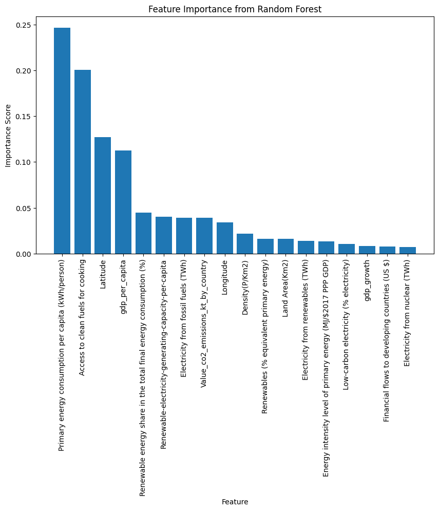

```python
from sklearn.ensemble import RandomForestClassifier
import matplotlib.pyplot as plt

train_data, test_data   = data[data['Year'] < cut_off_year] , data[data['Year'] >= cut_off_year]
X_train, y_train = train_data.drop(['Year', 'Access to electricity (% of population)','Access_encoded'], axis=1), train_data['Access_encoded']
X_test, y_test = test_data.drop(['Year', 'Access to electricity (% of population)','Access_encoded'], axis=1), test_data['Access_encoded']

rf_classifier = RandomForestClassifier(n_estimators=100, random_state=42)       # Initialize the Random Forest classifier
rf_classifier.fit(X_train, y_train)                                             # Fit the Random Forest model to the training data

feature_importance = rf_classifier.feature_importances_                         # To extract feature importance scores
sorted_indices = feature_importance.argsort()[::-1]                             # To sort feature importance scores in descending order
sorted_features = [X_train.columns[i] for i in sorted_indices]
sorted_importance = feature_importance[sorted_indices]

plt.figure(figsize=(10, 6))
plt.bar(range(len(sorted_features)), sorted_importance, align='center')
plt.xticks(range(len(sorted_features)), sorted_features, rotation=90)
plt.xlabel('Feature')
plt.ylabel('Importance Score')
plt.title('Feature Importance from Random Forest')
plt.show()
```

Now we can predict using the model fit using the classification tree model.

```python
y_pred = rf_classifier.predict(X_test)                  # Predict on the test set
print("Accuracy:", accuracy_score(y_test, y_pred))      # Evaluate the model
```

```
Accuracy: 0.9211428571428572
```

The model obtained using a classification tree method has a prediction accuracy that is approximately $92.1\%$ that is around 2% more accurate than the predictions made using the Logistic regression model.

## 6.3. RandomForest Regression

Since the classification model's accuracy was not up to our expectation, we turn to regression models to discover if they work better for our dataset. In regression we don't need to encode our target variable into categories anymore. We will use the column "Access to Electricity“ as our target variable.

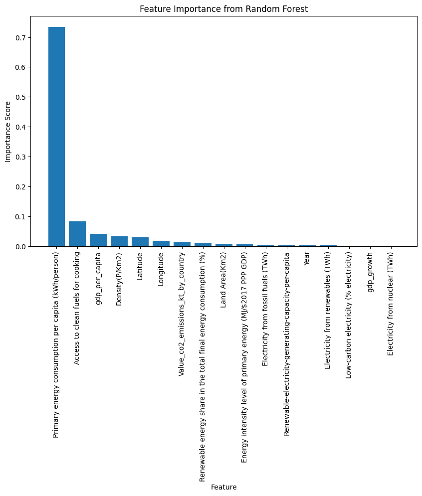

```python
data= original_df.copy()
data.drop(["Financial flows to developing countries (US $)","Renewables (% equivalent primary energy)"],axis=1,inplace=True)

knn_imputer = KNNImputer(n_neighbors=5)
data = pd.DataFrame(knn_imputer.fit_transform(data.drop('Entity',axis=1)),columns = knn_imputer.get_feature_names_out())

train = data[data['Year'] <= cut_off_year]
test = data[data['Year'] > cut_off_year]
x_train = train.drop("Access to electricity (% of population)",axis=1)
y_train = train["Access to electricity (% of population)"]
x_test = test.drop("Access to electricity (% of population)",axis=1)
y_test = test["Access to electricity (% of population)"]

rf_model  = RandomForestRegressor(max_depth=10,random_state=42)
rf_model.fit(x_train,y_train)

feature_importance = rf_model.feature_importances_
sorted_indices = feature_importance.argsort()[::-1]
sorted_features = [x_train.columns[i] for i in sorted_indices]
sorted_importance = feature_importance[sorted_indices]

plt.figure(figsize=(10, 6))
plt.bar(range(len(sorted_features)), sorted_importance, align='center')
plt.xticks(range(len(sorted_features)), sorted_features, rotation=90)
plt.xlabel('Feature')
plt.ylabel('Importance Score')
plt.title('Feature Importance from Random Forest')
plt.show()
```

```python
pred = rf_model.predict(x_test)
r2 = r2_score(y_test,pred)
mse = mean_squared_error(y_test,pred)
mae = mean_absolute_error(y_test,pred)
print(f'Coefficient of determination: {r2:.3f}\nMean Squared Error MSE:{mse:.2f}\nMean Absolute Error (MAE):{mae:.3f}')
```

```
Coefficient of determination: 0.950
Mean Squared Error MSE:31.96
Mean Absolute Error (MAE):3.078
```

In regression, the MSE measures the average difference between predicted and actual values. Smaller values of MSE are better and 0 means perfect prediction. In this particular case, the model's $MSE \approx31.96$.

The coefficient of determination: $R^2$ measures the proportion of varience in dependent variables that are captured by the model. Our Random Forest Regressor yields a high $R^2$ of 95%.

## 6.4. Gradient Boosting Model

[output not shown]

```
   Learning_Rate        R2       MAE
0            0.1  0.959760  2.770426
1            0.2  0.962478  2.653323
2            0.3  0.958981  2.819748
3            0.4  0.958421  2.763903
4            0.5  0.958210  2.903726
5            0.6  0.954920  3.065945
6            0.7  0.940033  3.408695
7            0.8  0.939889  3.411608
8            0.9  0.921292  3.805705
9            1.0  0.912770  4.011159
```

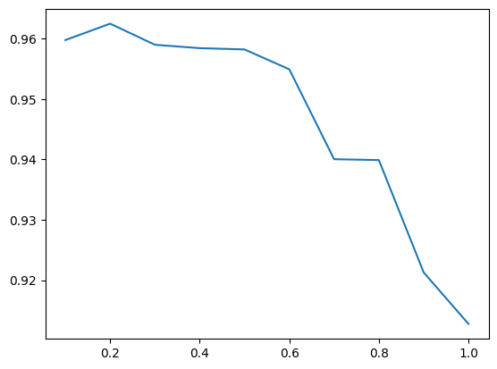

```python
from sklearn.ensemble import HistGradientBoostingRegressor

learning_rate = []
r2 = []
mae = []

for learning in np.linspace(0.1,1,10):
    clf = HistGradientBoostingRegressor(learning_rate=learning,max_depth=10,random_state=42)
    clf.fit(x_train,y_train)
    pred = clf.predict(x_test)
    r2.append(r2_score(y_test,pred))
    mae.append(mean_absolute_error(y_test,pred))
    learning_rate.append(learning)
table = pd.DataFrame({"Learning_Rate":learning_rate,
                      "R2":r2,
                      "MAE":mae})
print(table)
plt.plot("Learning_Rate","R2",data = table)
```

From our experiment we can see when learning rate is 0.2 the model gives the highest $R^2$. We will use $learning rate = 0.2$ to train our model.

```python
clf = HistGradientBoostingRegressor(learning_rate=0.2,max_depth=10)
clf.fit(x_train,y_train)
pred = clf.predict(x_test)
r2 = r2_score(y_test,pred)
mse = mean_squared_error(y_test,pred)
mae = mean_absolute_error(y_test,pred)
print(f'Coefficient of determination: {r2:.3f}\nMean Squared Error MSE:{mse:.2f}\nMean Absolute Error (MAE):{mae:.3f}')
```

```
Coefficient of determination: 0.962
Mean Squared Error MSE:24.04
Mean Absolute Error (MAE):2.653
```

Here we are glad to see a slight improvement in $R^2$, $MSE$ and $MAE$ over our RandomForest Model.

## 6.5. LightGBM Model

LightGBM is another tree baed model that utilizes gradient boosting. It carries out leaf-wise growth instead of level wise growth and is supposed to yield more loss reduction and higher accuracy. Again we will try to iterate over different num_leaves to find the best number to yield the best performance.

```
   num_leaves        R2       MAE
0          10  0.962947  2.699375
1          20  0.965147  2.605231
2          30  0.964519  2.590047
3          40  0.964240  2.553186
4          50  0.960892  2.597609
5          60  0.962505  2.524063
6          70  0.962307  2.567445
7          80  0.962905  2.562136
8          90  0.962989  2.542465
```

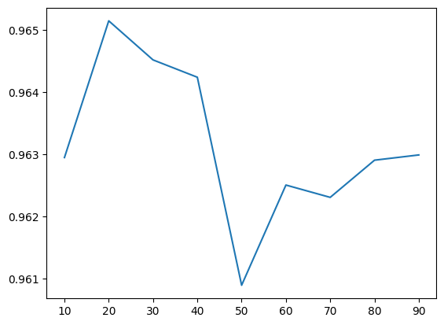

```python
from lightgbm import LGBMRegressor
nleaves = []
r2 = []
mae = []

for n in range(10,100,10):
    lgbm = LGBMRegressor(num_leaves=n, max_depth=20, n_estimators=300, n_jobs=-1,random_state=42,verbose = -1)
    lgbm.fit(x_train,y_train)
    pred = lgbm.predict(x_test)
    r2.append(r2_score(y_test,pred))
    mae.append(mean_absolute_error(y_test,pred))
    nleaves.append(n)
table = pd.DataFrame({"num_leaves":nleaves,
                      "R2":r2,
                      "MAE":mae})
print(table)
plt.plot("num_leaves","R2",data = table)
```

It looks like the 20 leaves gives the best result but the difference is minimal.

Yet again we will use the same procedure to determine the best number of trees.

```
   n_estimators        R2       MAE
0            50  0.946926  3.382463
1           100  0.958637  2.877914
2           150  0.962180  2.733461
3           200  0.963445  2.687651
4           250  0.964609  2.636792
5           300  0.965147  2.605231
6           350  0.965702  2.584276
7           400  0.965989  2.572568
8           450  0.966210  2.569462
```

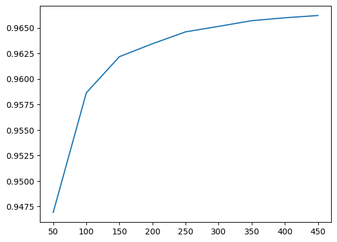

```python
ntree = []
r2 = []
mae = []

for n in range(50,500,50):
    lgbm = LGBMRegressor(num_leaves=20, max_depth=20, n_estimators=n, n_jobs=-1,random_state=42,verbose = -1)
    lgbm.fit(x_train,y_train)
    pred = lgbm.predict(x_test)
    r2.append(r2_score(y_test,pred))
    mae.append(mean_absolute_error(y_test,pred))
    ntree.append(n)
table = pd.DataFrame({"n_estimators":ntree,
                      "R2":r2,
                      "MAE":mae})
print(table)
plt.plot("n_estimators","R2",data = table)
```

Looks like dinimishing return occurs upward of 250 trees. We will use 250 trees to avoid potential overfitting.

```python
model = LGBMRegressor(num_leaves=20,max_depth=20, n_estimators=250, n_jobs=-1,random_state=42,verbose=-1)
model.fit(x_train,y_train)
pred = model.predict(x_test)
r2 = r2_score(y_test,pred)
mse = mean_squared_error(y_test,pred)
mae = mean_absolute_error(y_test,pred)
print(f'Coefficient of determination: {r2:.3f}\nMean Squared Error MSE:{mse:.2f}\nMean Absolute Error (MAE):{mae:.3f}')
```

```
Coefficient of determination: 0.965
Mean Squared Error MSE:22.68
Mean Absolute Error (MAE):2.637
```

The performance improvement over gradient boosting model is neglectable considering the randomness.

Now we will look at the feature importance of the LightGBM Model.

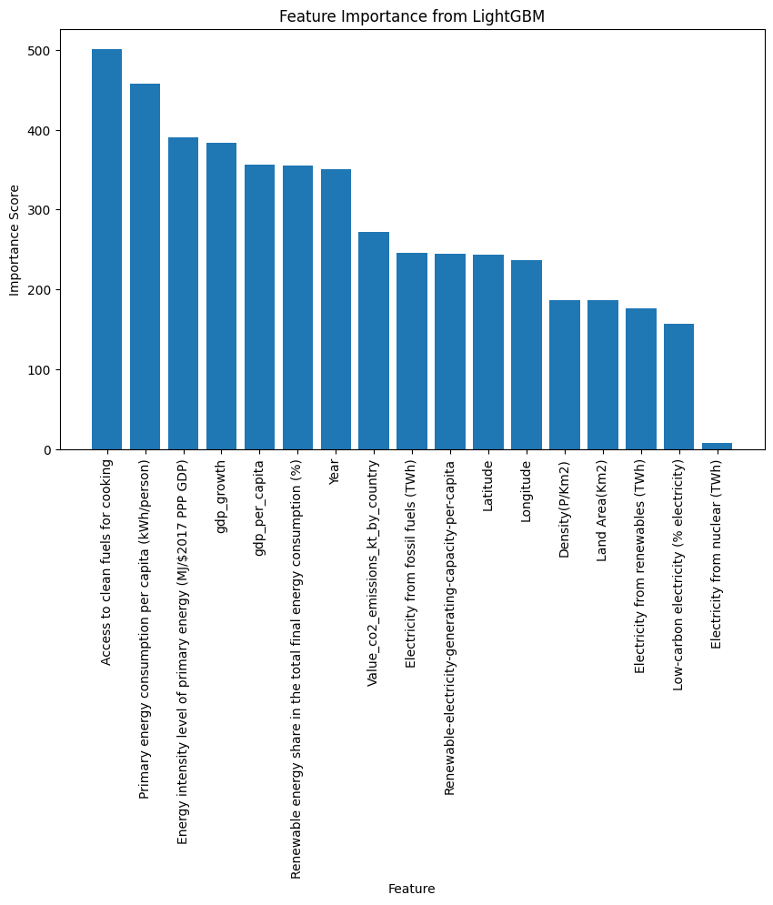

```python
feature_importance = model.feature_importances_
sorted_indices = feature_importance.argsort()[::-1]
sorted_features = [x_train.columns[i] for i in sorted_indices]
sorted_importance = feature_importance[sorted_indices]

plt.figure(figsize=(10, 6))
plt.bar(range(len(sorted_features)), sorted_importance, align='center')
plt.xticks(range(len(sorted_features)), sorted_features, rotation=90)
plt.xlabel('Feature')
plt.ylabel('Importance Score')
plt.title('Feature Importance from LightGBM')
plt.show()
```

The number one feature is 'Access to clean fuels for cooking', which if you recall, is insignificant in OLS. The importance score is a lot more evenly distributed comparing to the Random Forest Model.

## 7. Conclussions

Note that we cannot apply cross-validation techniques since our dataset is a time-series. It doesn't make sense to predict the past using future data. Our training-testing split is one time and final.

It's interesting that the highest importance for our Forest classifier method is *'Primary energy consumption per capita'* while in the correlation matrix the correlation between this variable and the target variable is not the highest, only 0.45. Here's why: Random forest classifiers are capable of capturing complex non-linear relationships between features and the target variable. They can identify interactions and combinations of features that contribute significantly to the predictive power of the model. On the other hand, correlation coefficients measure linear relationships between variables. In this case the Primary energy consumption has a non-linear relationship with the target variable, which can be observed in the scatter plot.

## 8. References.

[1] Martin, “Energy,” United Nations Sustainable Development. Accessed: Feb. 02, 2024. [Online]. Available: https://www.un.org/sustainabledevelopment/energy/

[2] “World Energy Outlook 2022 – Analysis,” IEA. Accessed: Feb. 02, 2024. [Online]. Available: https://www.iea.org/reports/world-energy-outlook-2022

[3] “Global Data on Sustainable Energy (2000-2020).” Accessed: Feb. 02, 2024. [Online]. Available: https://www.kaggle.com/datasets/anshtanwar/global-data-on-sustainable-energy

[4] "A random forest classifier.". https://scikit-learn.org/stable/modules/generated/sklearn.ensemble.RandomForestClassifier.html